# imaginary_triples_backup

### Pythagorean Triples and Imaginary Numbers

Here is what I discovered so far about pythagorean triples from playing with imaginary numbers in $Q1$ of the real/imaginary plane. You can generate a unique non trivial triple by choosing a cooridinate pair. I learned this from 3Blue1Brown one of my favorite youtube math shows. [Here](https://www.youtube.com/watch?v=QJYmyhnaaek) is a link to that particular show.

If one picks an ordered pair with the real part a smaller $\mathbb{N}$atural mumber than the other we will get a composite number with a minus in it. But we can make the exact same triangle with the pair reversed and the only change is the minus sign in the complex number. If we choose a natural number and an imaginary part that are the same number then we get a vertical vector on the $i$ axis. It even works with vectors with natural number lengths like the $(3,4)$ vector which we should right as the $(4,3)$ because different vector same triangle.

So lets cheat and use a computer algebra system and look at some graphs. We can typeset some of the ugly results in $\\LaTex$ after.

```python
# This gives objects to plot a vector and 3,4,5 triangle
vector00 = arrow((0,0),(4,3))
```

```python
# This is what the result of squaring the complex number is.
(4+3*i)^2
```

```
24*I + 7
```

```python
# Another vector
vector01 = arrow((0,0),(7,24), rgbcolor='green')
```

So we can see $7^2 + 24^2 = 25^2$ a unique triple! Here are the vectors.

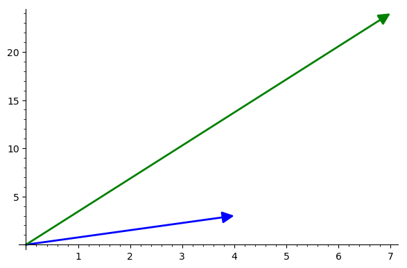

```python
plot(vector00 + vector01)
```

If we choose the vector $(13,7)$ as the real and imaginary part of the complex number that would have a square root in the answer.

```python
sqrt(13^2+7^2)
```

```
sqrt(218)
```

So that vector has a length of $\sqrt{218}$

```python
(13+7*i)^2
```

```
182*I + 120
```

```python
sqrt(182^2 + 120^2)
```

```
218
```

This gives us a pythagorean triple with sides of lengths $(120,182,218)$. **Woot!** Lets draw the vectors.

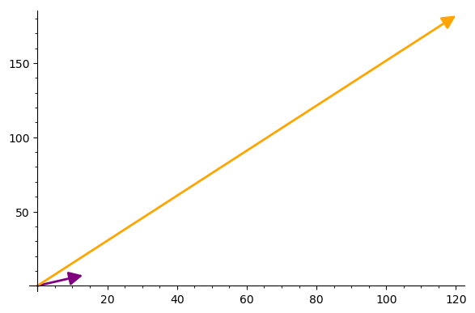

```python
vector02 = arrow((0,0),(13,7), rgbcolor='purple')
vector03 = arrow((0,0),(120,182), rgbcolor='orange')
plot(vector02 + vector03)
```

## Triples for fun

Lets generate a few more pythagorean triples and call it a day.

```python
(23 + 17*I)^2
```

```
782*I + 240
```

```python
sqrt(782^2+240^2)
```

```
818
```

```python
(23 + 11*I)^2
```

```
506*I + 408
```

```python
sqrt(506^2+ 408^2)
```

```
650
```

```python
(14+6*I)^2
```

```
168*I + 160
```

```python
sqrt(168^2+160^2)
```

```
232
```

## $240, 782, 818$

## $408, 506, 650$

## $160, 168, 232$